# Documentação de resultados usando R Markdown

Vanderlei Júlio Debastiani (vanderleidebastiani@yahoo.com.br)

05 Janeiro 2019

# Introdução

A documentação de resultados é uma etapa importante no desenvolvimento da ciência. R Markdown é uma ferramenta para produzir saídas formatadas de resultados do R, tornando as rotinas de análises e resultados mais simples e fácil de serem registrados e posteriormente compartilhados. O ponto de partida é um arquivo *.rmd*. Este arquivo é usado como um script do R, onde os comandos podem ser editados, comentados e executados normalmente. Usando um conjunto simplificado de sintaxe é possível adicionar textos, figuras, tabelas, links e outros elementos para complementar a documentação dos resultados. Por fim, os resultados podem ser facilmente formatados e exportados para vários formatos, incluindo HTML, PDF, RTF, MS Word e LaTeX. O objetivo deste tutorial é mostrar as opções básicas para documentação de resultados, usando como exemplo as saída no formato PDF.

# Estrutura do RMD

O arquivo *.rmd* é composto por difetentes seções, este arquivo é usado na função *render* do pacote *rmarkdown* para converter no formato de saída especificado.

## Cabeçalho YAML

A primeira seção é cabeçalho YAML (opcional) usada na função *render*. Argumentos de personalização das saída podem ser especificadas no cabeçalho ou diretamente na função *render*.

Essa seção começa com `---` e termina com `---`.

> `---`  
> `title: "Título"`  
> `author: "Nome"`  
> `date: "Data"`  
> `---`

## Texto formatado com R Markdown

O texto na saída pode ser formatado usando um conjunto simples de sintaxe. Algumas das opções básicas estão listados abaixo:

### Texto simples

Os textos simples podem ser usados sem qualquer sintaxe. Para iniciar um novo parágrafo é possível usar dois espaços no final ou deixar uma linha em branco.

### Formatação de texto básica

> `*itálico*` para *itálico*;  
> `**negrito**` para **negrito**;  
> `códigos` para `código textual`;  
> `superescrito^2^` para superescrito<sup>2</sup>;  
> `subescrito~2~` para subescrito<sub>2</sub>;  
> barra invertida para ignorar caracter especial *, ` e \;  
> `> bloco de citacação` para > bloco de citação;

### Cabeçalhos

Os cabeçalhos são especificados usando o #.

> `# Cabeçalhos 1`  
> `## Cabeçalhos 2`  
> `### Cabeçalhos 3`  
> `#### Cabeçalhos 4`  
> `##### Cabeçalhos 5`

### Equações

Equações são especificadas usando `$` ou equações em bloco usando `$$`:

> `$A = \pi*r^{2}$` para $A = \pi*r^{2}$;
> `$$A = \pi*r^{2}$$` para
> $$A = \pi*r^{2}$$

### Links

> `<http://www.google.com>` para http://www.google.com  
> `[Site de Busca](wwww.google.com)` para Site de Busca

### Listas

Para listas não ordenadas são definidas pelos caracteres *, + e -:

> `* item 1`  
> `+ sub-item 1`  
> `+ sub-item 2`  
> `- sub-sub-item 1`  
> `* item 2`
- item 1
  - sub-item 1
  - sub-item 2
    - sub-sub-item 1
- item 2

Para listas ordenadas:

> `1. item 1`  
> `2. item 2`  
> `i) sub-item 1`  
> `A. sub-sub-item 1`
1. item 1
2. item 2
   1. sub-item 1  
      A. sub-sub-item 1

## Códigos R (usando chunks)

Para inserir códigos de R, como scripts e resultados, é possível usar a sintaxe chunk que começa com ` ` ` { r } e termina com ` ` `. Uma ou mais linhas podem ser incluídas no mesmo bloco.

Exemplo:

> ```{r}  
> `data(CO2)`  
> `head(CO2)`  
> `summary(CO2[,4:5])`  
> ```

```r
data(CO2)
head(CO2)
```

```
##   Plant   Type  Treatment conc uptake
## 1   Qn1 Quebec nonchilled   95   16.0
## 2   Qn1 Quebec nonchilled  175   30.4
## 3   Qn1 Quebec nonchilled  250   34.8
## 4   Qn1 Quebec nonchilled  350   37.2
## 5   Qn1 Quebec nonchilled  500   35.3
## 6   Qn1 Quebec nonchilled  675   39.2
```

```r
summary(CO2[,4:5])
```

```
##       conc          uptake
##  Min.   :  95   Min.   : 7.70
##  1st Qu.: 175   1st Qu.:17.90
##  Median : 350   Median :28.30
##  Mean   : 435   Mean   :27.21
##  3rd Qu.: 675   3rd Qu.:37.12
##  Max.   :1000   Max.   :45.50
```

Exemplo:

> ```{r, highlight = FALSE}  
> `# Show R version`  
> `getRversion()`  
> ```

```
# Show R version
getRversion()
```

```
## [1] '3.5.2'
```

## Gráficos

Os resultados gráficos podem ser incluídos no documento com os resultado da saída, exatamente como as funções de *plot* do R. Por padrão, os tamanhos das figuras são especifidos no cabeçalho YAML ou na função *render*, mas também os tamanhos podem ser especificados para cada gráfico usando as opções do chunk.

Exemplo:

> ```{r, fig.width = 4, fig.height = 4}  
> plot(1:10,1:10)  
> ```

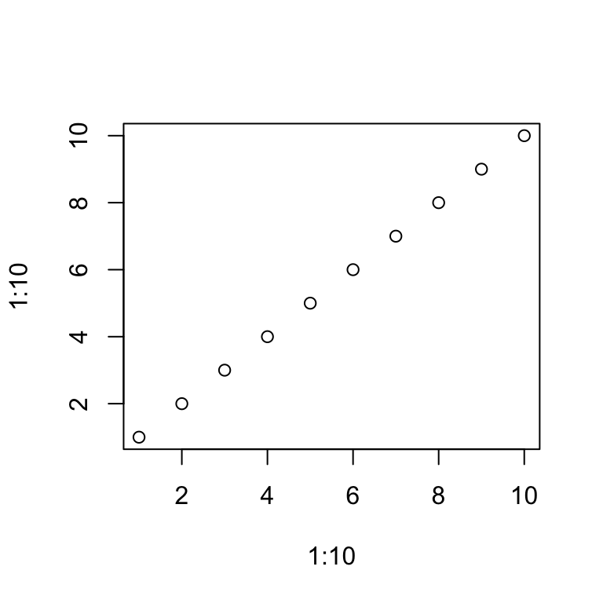

```r
plot(1:10, 1:10)
```

## Tabelas

As tabelas podem ser incluídas usando a opção de impressão (*print*) nos códigos R (código chunks) ou usando as funções para formatar dados em tabelas disponíveis no R. Alguns exemplos são as funções *kable* do pacote *knitr*, *xtable* do pacote *xtable* e a função *stargazer* do pacote *stargazer*.

Exemplo:

> ```{r}  
> `require(knitr)`  
> `CO2[1:10,]`  
> `knitr::kable(CO2[1:10,], caption = "Tabela com kable")`  
> ```

```r
require(knitr)
CO2[1:10,]
```

```
##    Plant   Type  Treatment conc uptake
## 1    Qn1 Quebec nonchilled   95   16.0
## 2    Qn1 Quebec nonchilled  175   30.4
## 3    Qn1 Quebec nonchilled  250   34.8
## 4    Qn1 Quebec nonchilled  350   37.2
## 5    Qn1 Quebec nonchilled  500   35.3
## 6    Qn1 Quebec nonchilled  675   39.2
## 7    Qn1 Quebec nonchilled 1000   39.7
## 8    Qn2 Quebec nonchilled   95   13.6
## 9    Qn2 Quebec nonchilled  175   27.3
## 10   Qn2 Quebec nonchilled  250   37.1
```

```r
knitr::kable(CO2[1:10,], caption = "Tabela com kable")
```

Tabela 1: Tabela com kable

| Plant | Type | Treatment | conc | uptake |
| --- | --- | --- | --- | --- |
| Qn1 | Quebec | nonchilled | 95 | 16.0 |
| Qn1 | Quebec | nonchilled | 175 | 30.4 |
| Qn1 | Quebec | nonchilled | 250 | 34.8 |
| Qn1 | Quebec | nonchilled | 350 | 37.2 |
| Qn1 | Quebec | nonchilled | 500 | 35.3 |
| Qn1 | Quebec | nonchilled | 675 | 39.2 |
| Qn1 | Quebec | nonchilled | 1000 | 39.7 |
| Qn2 | Quebec | nonchilled | 95 | 13.6 |
| Qn2 | Quebec | nonchilled | 175 | 27.3 |
| Qn2 | Quebec | nonchilled | 250 | 37.1 |

# Exportar o arquivo *.rmd* nos formatos de saída

A função *render* é usada para exportar o arquivo *.rmd* no documento final formatado. A função carrega o arquivo e converte para o formato de saída especificado no cabeçalho YAML ou diretamente na função. As opções para a saída são descritas na funções *pdf_document*, *html_document*, *rtf_document* e *word_document*.

Exemplo:

> `require(rmarkdown)`  
> `require(knitr)`  
> `render("input.Rmd", pdf_document(keep_tex = TRUE))`

# Conclusão

O objetivo deste texto foi introduzir conceitos básicos para documentação de resultados usando R Markdown. Espero que este texto tenha sido útil e, por favor, avise-me se tiver dúvidas ou sugestões sobre este texto.

# Mais informações

Outros textos e tutoriais sobre R podem ser encontrados em https://vanderleidebastiani.github.io/tutoriais.

# Referências

- R Core Team. 2018. **R Language Definition**. https://cran.r-project.org/doc/manuals/R-lang.html
- R Markdown. 2018. **R Markdown**. http://rmarkdown.rstudio.com
- Knitr. 2018. **knitr - Elegant, flexible, and fast dynamic report generation with R**. https://yihui.name/knitr/